# Biomarker analysis of GS-US-428-4194 (PRIMIS)

A Phase 3, randomized, double-blinded, placebo-controlled study evaluating the safety, tolerability, and efficacy of Cilofexor in non-cirrhotic subjects with primary sclerosing cholangitis

Kaiyi Zhu[^1]

2023-11-08

# 1 Background

- Primary sclerosing cholangitis (PSC) is a chronic progressive cholestatic liver disease with a poorly understood pathogenesis
- There are no approved therapies that can improve clinical outcomes in patients with PSC
- Cilofexor (CILO) is a selective, nonsteroidal farnesoid X receptor agonist
- [A phase 2 trial](https://doi.org/10.1002/hep.30509) in patients with non-cirrhotic PSC showed that treatment with CILO led to significant improvements in liver biochemistries and markers of cholestasis, and was well tolerated
- [PRIMIS](https://doi.org/10.1186/s12876-023-02653-2) is a phase 3, double-blind, randomized, placebo-controlled, multi-center trial (NCT03890120) designed to assess the efficacy and safety of CILO for the treatment of non-cirrhotic PSC

# 2 Data preprocessing

## 2.1 Load required packages

```r
library(haven)
library(dplyr)
library(tidyverse)
library(ggplot2)
library(ggpubr)
library(reshape2)
library(pROC)
library(gtsummary)
library(lsmeans)
```

## 2.2 Incorporate relevant information from ADSL and ADLB

```r
ADSL_PATH <- '/biometrics_prod/projects/p428/s4284194/biomarker/final/version2/adamdata/adsl.sas7bdat'
ADLB_PATH <- '/biometrics_prod/projects/p428/s4284194/biomarker/final/version2/adamdata/adlb.sas7bdat'
ADBK_PATH = '/biometrics_prod/projects/p428/s4284194/biomarker/final/version2/adamdata/adbk.sas7bdat'
```

```r
adsl <- read_sas(ADSL_PATH)

adlb <- read_sas(ADLB_PATH) %>%
  filter(ANL01FL == 'Y')

adbk <- read_sas(ADBK_PATH) %>%
  filter(ANL01FL == 'Y') %>%
  left_join(., select(adsl, USUBJID, IBD, BUDCA, BLUDWIG, BBMI, FUTILFL)) %>%
  left_join(., select(adlb, USUBJID, TRT01A, AVISIT, PARAMCD, ANRHI, R2ANRHI)) %>%
  mutate(BLUDWIG_CAT = factor(ifelse(BLUDWIG < 3, 'F0-2', 'F3'))) %>%
  mutate(BLUDWIG = paste0('F', BLUDWIG)) %>%
  mutate(TRT01A = factor(str_replace(TRT01A, ' 100 mg', ''),
                         levels = c('Placebo', 'CILO'), ordered = TRUE)) %>%
  mutate(PARAMCD = ifelse(PARAMCD == 'CHA', 'CA',
                          ifelse(PARAMCD == 'GUCDA', 'GUDCA',
                                 ifelse(PARAMCD == 'TUCDA', 'TUDCA', PARAMCD))))
```

## 2.3 Group biomarkers into categories

```r
histology <- c('LUDWFBS',
               'ALPHASMA', 'COLLAGEN',
               'BIDULCK7', 'DUCRCK7', 'PRDUCFBS')

PD <- c('C4', 'FGF19')

inflammation <- c('CRP', 'CALPRO')

NIT_fibrosis <- c('APRI', 'FIB4', 'FIBSCAN',
                  'ELFSCORE', 'P3NP', 'HYALUAC', 'TIMP1')

liver_biochemistry <- c('ALT', 'AST', 'GGT', 'ALP', 'BILI', 'ALB',
                        'CK18M30', 'CK18M65')

BA = list(
  'Primary' = c('CA', 'CDCA'),
  'Conjugated Primary' = c('GCA', 'TCA', 'GCDCA', 'TCDCA'),
  'Secondary' = c('DCA', 'LCA', 'UDCA'),
  'Conjugated Secondary' = c('GDCA', 'TDCA', 'GLCA', 'TLCA', 'GUDCA', 'TUDCA'),
  'Total' = c('METATBA', 'TBMUDCA', 'PRMTBA', 'SBMUDCA')
)

BA_derived <- c('METATBA', 'SECTBA', 'PRMTBA', 'CONJTBA', 'UNCNTBA',
                'SBMUDCA', 'TBMUDCA',
                'CA2CDCA', 'LTH2TBA', 'PRM2SEC', 'PRM2TBA', 'SEC2TBA')
```

# 3 Baseline analysis

```r
adbk_BL <- adbk %>%
  filter(AVISIT == 'Baseline')
```

## 3.1 Pairwise correlations between all biomarkers

```r
## Function of clustering correlation matrix
reorder_cormat <- function(cormat){
  dd <- as.dist((1-cormat)/2)
  hc <- hclust(dd, method = 'ward.D2')
  cormat <- cormat[hc$order, hc$order]
}
```

```r
## Prepare the data frame to calculate correlation
df_all <- adbk_BL %>%
  filter(PARAMCD %in% c(# 'LUDWFBS',
                        NIT_fibrosis[1:4],
                        # unlist(BA[1:4]),
                        unlist(BA[5])[-1],
                        inflammation,
                        PD,
                        liver_biochemistry)) %>%
  select(USUBJID, PARAMCD, AVAL) %>%
  distinct() %>%
  pivot_wider(values_from = AVAL, names_from = PARAMCD) %>%
  column_to_rownames('USUBJID')

colnames(df_all)[c(17:19)] <- c('Primary BA', 'Secondary BA', 'Total BA')
```

```r
df_ludwig <- adbk_BL %>%
  filter(PARAMCD == 'LUDWFBS') %>%
  select(USUBJID, AVAL) %>%
  rename(FibrosisStage = AVAL) %>%
  distinct() %>%
  column_to_rownames('USUBJID')

cor_ludwig <- matrix(NA, nrow = ncol(df_all), ncol = 3,
                     dimnames = list(c(PD, liver_biochemistry, NIT_fibrosis[1:4], 'Total BA', 'Primary BA', 'Secondary BA', inflammation),
                                     c('rho', 'p.value', 'group')))
for (i in rownames(cor_ludwig)) {

  res <- cor.test(df_all[,i], df_ludwig$FibrosisStage, method = 'spearman')
  cor_ludwig[i, "rho"] <- res$estimate
  cor_ludwig[i, "p.value"] <- res$p.value

}
cor_ludwig <- as.data.frame(cor_ludwig)
cor_ludwig$biomarker <- factor(rownames(cor_ludwig),
                               levels = c(PD, liver_biochemistry, NIT_fibrosis[1:4], 'Total BA', 'Primary BA', 'Secondary BA', inflammation), ordered = TRUE)
cor_ludwig$clinical <- 'Ludwig Fibrosis Stage'
cor_ludwig$group <- c(rep('PD', length(PD)), rep('Liver injury', length(liver_biochemistry)), rep('Fibrosis NITs', 4),
                      rep('Bile Acids', length = 3), rep('Inflam', length(inflammation)))
cor_ludwig$group <- factor(cor_ludwig$group,
                           levels = c('PD', 'Liver injury', 'Fibrosis NITs', 'Bile Acids', 'Inflam'), ordered = TRUE)
cor_ludwig$p.adj <- p.adjust(cor_ludwig[, 'p.value'], method = 'bonferroni')
cor_ludwig$star <- cut(cor_ludwig$p.adj, breaks = c(-Inf, c(0.0001, 0.001, 0.01), 1),
            labels = c('***', '**', '*', ''))
```

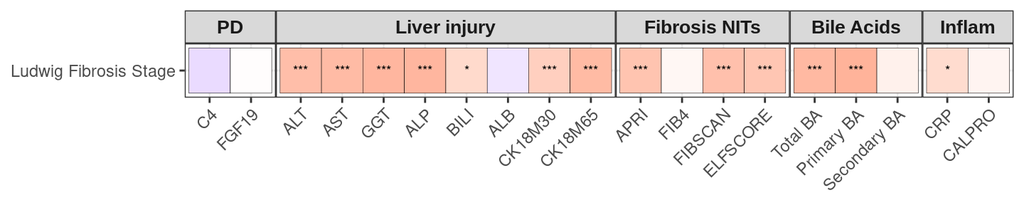

```r
ggplot(cor_ludwig, aes(x = biomarker, y = clinical, fill = rho)) +
  facet_grid(cols = vars(group), scales= "free", space = 'free') +
  geom_tile(color = 'black') +
  scale_fill_gradient2(low = 'blue', high = 'red', mid = 'white',
                       midpoint = 0, limit = c(-1,1), space = 'Lab') +
  geom_text(aes(label = star), color = 'black', size = 2.5)+
  theme_bw() +
  theme(axis.text.x = element_text(angle = 45, vjust = 1, hjust = 1),
        axis.title = element_blank(),
        # panel.border = element_blank(),
        strip.text = element_text(family = "Arial", size = 10, face = "bold"),
        legend.position = 'none',
        panel.spacing.x = unit(0, "lines")
        )
```

```r
## Calculate pairwise Spearman correlation
cormat <- round(cor(df_all, use = 'na.or.complete', method = 'spearman'), 2)
cormat <- reorder_cormat(cormat)
# cormat[lower.tri(cormat,diag = FALSE)] <- NA
melted_cormat <- melt(cormat, na.rm = TRUE)
melted_cormat$Var1 <- factor(melted_cormat$Var1,
                             levels = c(PD, liver_biochemistry, NIT_fibrosis[1:4], 'Total BA', 'Primary BA', 'Secondary BA', inflammation),
                             ordered = TRUE)
melted_cormat$Var2 <- factor(melted_cormat$Var2,
                             levels = c(PD, liver_biochemistry, NIT_fibrosis[1:4], 'Total BA', 'Primary BA', 'Secondary BA', inflammation),
                             ordered = TRUE)

pvalues <- rep(NA, length = nrow(melted_cormat))
coef <- rep(NA, length = nrow(melted_cormat))
for (i in 1:nrow(melted_cormat)) {

  if(is.na(melted_cormat$value[i]))
    next
  else{
    res <- cor.test(df_all[, as.character(melted_cormat$Var1)[i]],
                    df_all[, as.character(melted_cormat$Var2)[i]],
                    method = 'spearman')
    pvalues[i] <- res$p.value
    coef[i] <- res$estimate
  }

}

## Correct P-values by Bonferroni for multiple testing
bonf_divider = (ncol(df_all) * (ncol(df_all)-1))/2
star <- cut(pvalues, breaks = c(-Inf, c(0.0001, 0.001, 0.01)/bonf_divider, 1),
            labels = c('***', '**', '*', ''))
melted_cormat$star = star
melted_cormat$star[which(melted_cormat$rho == 1)] = ''
melted_cormat$rho = round(coef, digits = 2)
```

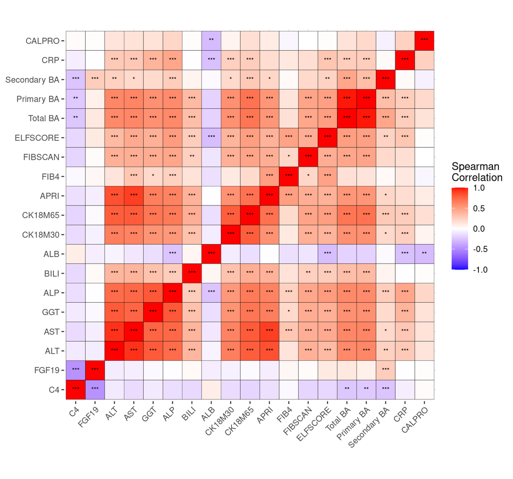

```r
## Heatmap showing the correlation
ggplot(melted_cormat, aes(Var2, Var1, fill = rho)) +
  geom_tile(color = 'black') +
  scale_fill_gradient2(low = 'blue', high = 'red', mid = 'white',
                       midpoint = 0, limit = c(-1,1), space = 'Lab',
                       name = 'Spearman\nCorrelation') +
  geom_text(aes(Var2, Var1, label = star), color = 'black', size = 2.5) +
  # geom_text(aes(Var2, Var1, label = rho), color = 'black', size = 2.5) +
  theme_bw() +
  theme(axis.text.x = element_text(angle = 45, vjust = 1, hjust = 1),
         axis.title = element_blank(),
        panel.border = element_blank()
        ) +
  coord_fixed()
```

- Ludwig fibrosis stage is positively associated with noninvasive fibrosis tests (FibroScan, ELF, APRI), liver biochemistry, and conjugated primary bile acids
- Most negative correlation was between C4 and FGF19 (rho = -0.47)

## 3.2 Biomarker association with Ludwig fibrosis stages

Same functions can also be used for evaluating association with other categorical features (e.g. UDCA use, IBD)

```r
df <- adbk_BL %>%
  select(USUBJID, TRT01A, RACE, AGE, SEX, BBMI, IBD, BUDCA, BLUDWIG, BLUDWIG_CAT, PARAMCD, AVAL) %>%
  distinct()

## You can specify the biomarker of interest
biomarker <- 'ELFSCORE'
df_plot <- df %>%
  filter(PARAMCD == biomarker)

## P values were derived by Wilcoxon Rank Sum test
wilcox.test(df_plot$AVAL ~ df_plot$BLUDWIG_CAT)
```

```
##
##  Wilcoxon rank sum test with continuity correction
##
## data:  df_plot$AVAL by df_plot$BLUDWIG_CAT
## W = 10074, p-value = 1.257e-08
## alternative hypothesis: true location shift is not equal to 0
```

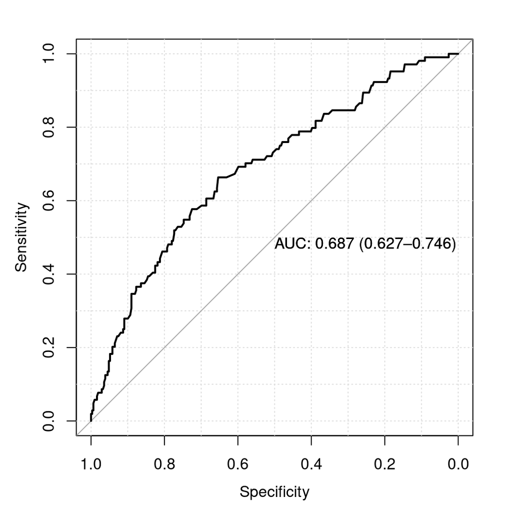

```r
## Calculate AUROC of biomarker BL values as the effect size
roc <- roc(df_plot$BLUDWIG_CAT, df_plot$AVAL,
           levels = c('F0-2', 'F3'),
           grid= TRUE,
           ci = TRUE, ci.alpha = 0.95,
           plot = TRUE, print.auc = TRUE)
```

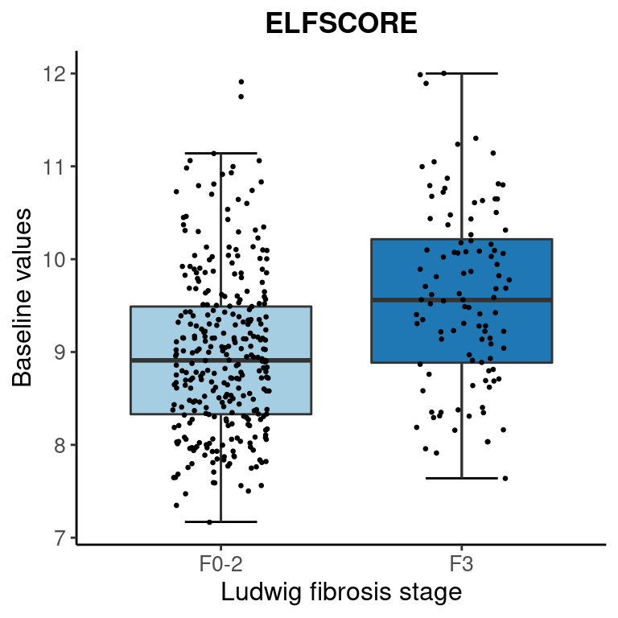

```r
## Boxplot
# As for FibroScan, log-transformation of y-axis may be considered
ggplot(df_plot, aes(x = BLUDWIG_CAT, y = AVAL, fill = BLUDWIG_CAT)) +
  stat_boxplot(geom = 'errorbar', width = 0.3) +
  geom_boxplot(outlier.shape = NA) +
  scale_fill_brewer(palette = 'Paired') +
  geom_jitter(position=position_jitter(0.2), size = 0.5) +
  labs(x = 'Ludwig fibrosis stage',
       y = 'Baseline values',
       title = biomarker) +
  # scale_y_continuous(trans = 'log10') +
  theme_classic()+
  theme(legend.position = 'none',
        plot.title = element_text(hjust = 0.5, face = 'bold'),
        axis.text = element_text(size = 10),
        axis.title = element_text(size = 12))
```

## 3.3 Serum bile acids (BAs)

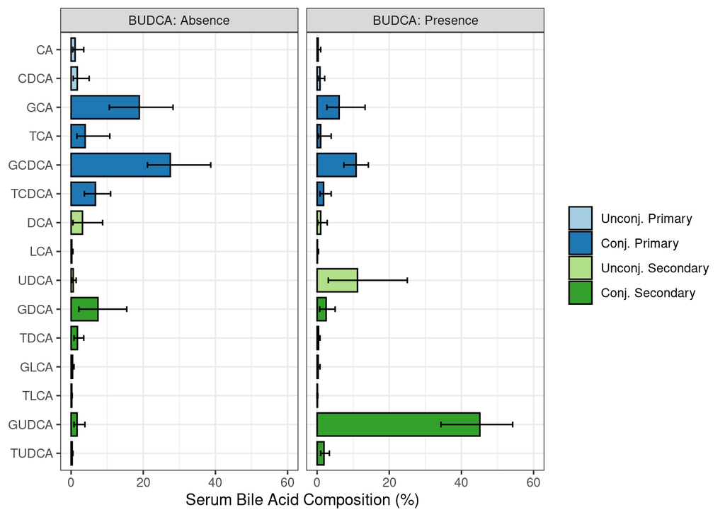

```r
## Composition of individual BAs

df_BA_total <- adbk_BL %>%
  filter(PARAMCD == 'METATBA') %>%
  select(USUBJID, TRT01A, AVAL) %>%
  rename(TotalBA = AVAL)

df_BA_summary <- adbk_BL %>%
  filter(PARAMCD %in% unlist(BA[1:4])) %>%
  mutate(PARAMCD = factor(PARAMCD, levels = rev(unlist(BA[1:4])), ordered = TRUE)) %>%
  select(USUBJID, TRT01A, AGE, SEX, BBMI, IBD, BUDCA, BLUDWIG, BLUDWIG_CAT, PARAMCD, AVAL) %>%
  left_join(df_BA_total) %>%
  mutate(PCT = round(AVAL/TotalBA*100, digits = 1)) %>%
  group_by(PARAMCD, BUDCA) %>%
  summarise(median = median(PCT, na.rm = TRUE),
                 Q1 = quantile(PCT, probs = 0.25, na.rm = TRUE),
                 Q3 = quantile(PCT, probs = 0.75, na.rm = TRUE)) %>%
  mutate(GROUP = ifelse(PARAMCD %in% BA$Primary, 'Unconj. Primary',
                        ifelse(PARAMCD %in% BA$`Conjugated Primary`, 'Conj. Primary',
                               ifelse(PARAMCD %in% BA$Secondary, 'Unconj. Secondary', 'Conj. Secondary')))) %>%
  mutate(GROUP = factor(GROUP, levels = c('Unconj. Primary', 'Conj. Primary', 'Unconj. Secondary', 'Conj. Secondary'),
                        ordered = TRUE))

ggplot(df_BA_summary, aes(x = PARAMCD, y = median, fill = GROUP)) +
  geom_bar(position = position_dodge(), stat = 'identity',
           width = 0.8,
           color = 'black') +
  geom_errorbar(aes(ymin = Q1, ymax = Q3),
                width = .2,
                position = position_dodge())+
  scale_fill_brewer(palette = 'Paired') +
  facet_wrap(~BUDCA, labeller = label_both) +
  ylim(c(0,60)) +
  labs(y = 'Serum Bile Acid Composition (%)',
       x = NULL) +
  coord_flip() +
  theme_bw() +
  theme(legend.position = 'right', legend.title = element_blank())
```

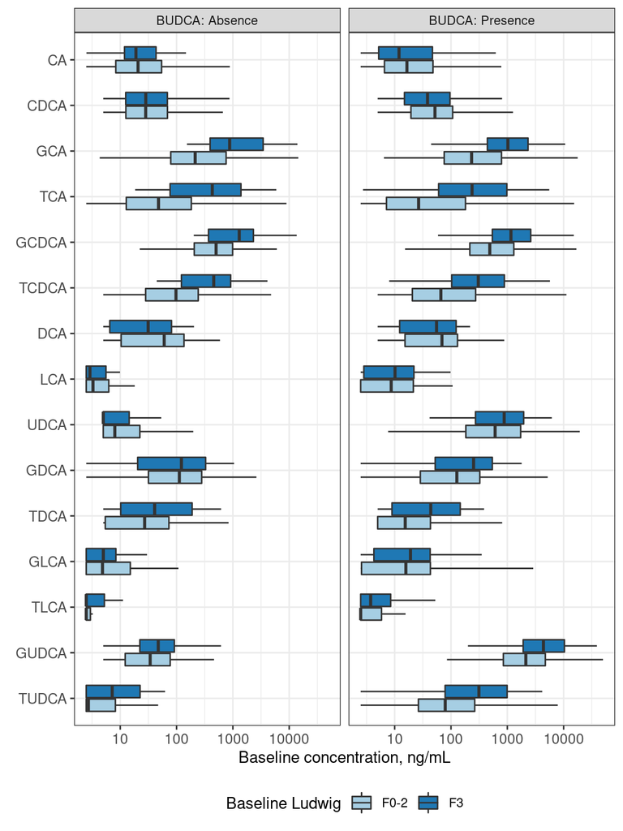

```r
df_BA <- adbk_BL %>%
  filter(PARAMCD %in% unlist(BA[-5])) %>%
  mutate(PARAMCD = factor(PARAMCD, ordered = T, levels = rev(unlist(BA[-5]))))

ggplot(df_BA, aes(x = PARAMCD, y = AVAL)) +
  geom_boxplot(aes(fill = BLUDWIG_CAT), outlier.shape = NA, width = 0.6) +
  scale_fill_brewer(palette = 'Paired') +
  labs(x = element_blank(),
       y = 'Baseline concentration, ng/mL',
       fill = 'Baseline Ludwig') +
  scale_y_continuous(trans = 'log10') +
  theme_bw()+
  facet_wrap(~BUDCA, labeller = label_both) +
  theme(legend.position = 'bottom',
        plot.title = element_text(hjust = 0.5, face = 'bold'),
        axis.text = element_text(size = 10),
        axis.title = element_text(size = 11)) +
  coord_flip()
```

## 3.4 Within F3 patients, imbalanced baseline liver biochemistry and conj. primary BAs were observed between treatment arms

Note that changes from baseline to week 96 in liver enzymes, bile acids are one of the secondary endpoints.

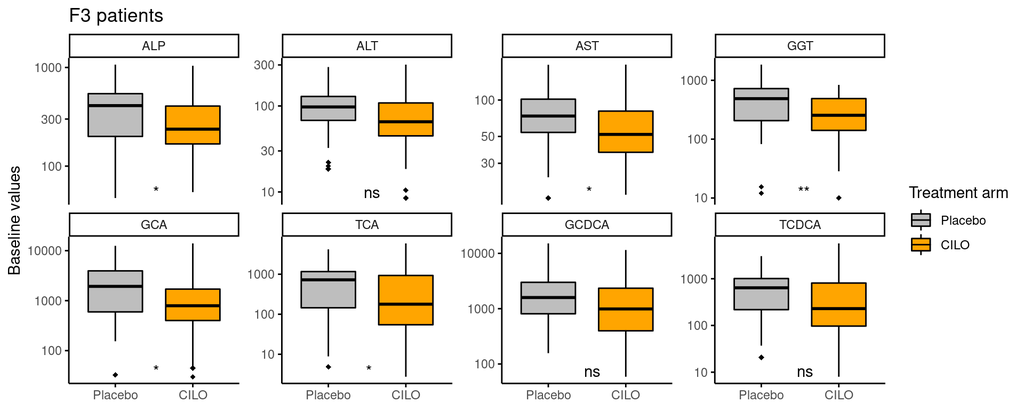

```r
df_plot <- df %>%
  filter(BLUDWIG_CAT == 'F3') %>%
  filter(PARAMCD %in% c('ALP', 'ALT', 'AST', 'GGT',
                        'GCA', 'TCA', 'GCDCA', 'TCDCA')) %>%
  mutate(PARAMCD = factor(PARAMCD, levels = c('ALP', 'ALT', 'AST', 'GGT',
                                              'GCA', 'TCA', 'GCDCA', 'TCDCA'),
                          ordered = TRUE)) %>%
  distinct()

p <- ggboxplot(df_plot,
          x = 'TRT01A',
          y = 'AVAL',
          yscale = 'log10',
          xlab = FALSE, ylab = 'Baseline values',
          fill = 'TRT01A',
          palette = c('grey', 'orange'),
          ggtheme = theme_classic(),
          outlier.shape = 18,
          facet.by = c('PARAMCD'), ncol = 4,
          scales = 'free_y') +
  stat_compare_means(aes(label = ..p.signif..),
                     method = 'wilcox.test',
                     label.y.npc = 'bottom', label.x.npc = 'center')

ggpar(p,
      title = 'F3 patients',
      legend.title = 'Treatment arm')
```

## 3.5 Characteristics comparison between the participants used for futility analysis and the others

The PRIMIS study was early terminated based on a pre-planned, interim futility analysis was performed after 160 participants had either completed week 96 or an early termination visit.

```r
df <- adbk_BL %>%
  select(USUBJID, TRT01A, RACE, AGE, SEX, BBMI, IBD, BUDCA, BLUDWIG, BLUDWIG_CAT, FUTILFL, PARAMCD, AVAL) %>%
  distinct() %>%
  pivot_wider(names_from = PARAMCD, values_from = 'AVAL')

print(table(df$FUTILFL))
```

```
##
##   N   Y
## 256 160
```

```r
## Change attributes for table presentation
df[] <- lapply(df, function(x) { attr(x, 'label') <- NULL; x })
attr(df$TBMUDCA, 'label') <- 'Total BA'
attr(df$PRMTBA, 'label') <- 'Primary BA'
attr(df$SBMUDCA, 'label') <- 'Secondary BA'

## Compare demographics
demog <- c('TRT01A', 'AGE', 'SEX', 'BBMI', 'BLUDWIG', 'BUDCA', 'IBD')
tbl_summary(select(df, FUTILFL, all_of(demog)),
                   by = FUTILFL, missing = 'no') %>%
  add_n() %>%
  add_p() %>%
  bold_labels() %>%
  modify_caption('**Patients who participated in fultility analysis vs. who did not**')
```

**Patients who participated in fultility analysis vs. who did not**

| **Characteristic** | **N** | **N**, N = 256<sup>1</sup> | **Y**, N = 160<sup>1</sup> | **p-value**<sup>2</sup> |
| --- | --- | --- | --- | --- |
| TRT01A | 416 |  |  | >0.9 |
| Placebo |  | 86 (34%) | 53 (33%) |  |
| CILO |  | 170 (66%) | 107 (67%) |  |
| AGE | 416 | 41 (32, 53) | 45 (37, 55) | 0.015 |
| SEX | 416 |  |  | 0.4 |
| F |  | 102 (40%) | 57 (36%) |  |
| M |  | 154 (60%) | 103 (64%) |  |
| BBMI | 416 | 24.8 (22.7, 28.1) | 24.9 (22.7, 28.3) | >0.9 |
| BLUDWIG | 416 |  |  | 0.4 |
| F0 |  | 50 (20%) | 26 (16%) |  |
| F1 |  | 69 (27%) | 44 (28%) |  |
| F2 |  | 79 (31%) | 43 (27%) |  |
| F3 |  | 58 (23%) | 47 (29%) |  |
| BUDCA | 416 |  |  | 0.5 |
| Absence |  | 108 (42%) | 62 (39%) |  |
| Presence |  | 148 (58%) | 98 (61%) |  |
| IBD | 416 |  |  | 0.6 |
| N |  | 74 (29%) | 50 (31%) |  |
| Y |  | 182 (71%) | 110 (69%) |  |

<sup>1</sup> n (%); Median (IQR)  
<sup>2</sup> Pearson's Chi-squared test; Wilcoxon rank sum test

```r
## Compare baseline values of biomarkers
biomarkers <- c(PD, liver_biochemistry, inflammation, NIT_fibrosis[1:4], BA$Total[-1])
tbl_summary(select(df, FUTILFL, all_of(biomarkers)),
                   by = FUTILFL, missing = 'no') %>%
  add_n() %>%
  add_p() %>%
  bold_labels() %>%
  modify_caption('**Patients who participated in fultility analysis vs. who did not**')
```

**Patients who participated in fultility analysis vs. who did not**

| **Characteristic** | **N** | **N**, N = 256<sup>1</sup> | **Y**, N = 160<sup>1</sup> | **p-value**<sup>2</sup> |
| --- | --- | --- | --- | --- |
| C4 | 411 | 13 (7, 25) | 13 (6, 24) | 0.8 |
| FGF19 | 410 | 108 (64, 179) | 102 (61, 178) | 0.6 |
| ALT | 416 | 49 (26, 96) | 51 (28, 88) | 0.6 |
| AST | 416 | 37 (25, 65) | 40 (26, 62) | 0.5 |
| GGT | 416 | 138 (50, 301) | 172 (75, 385) | 0.12 |
| ALP | 416 | 167 (104, 272) | 189 (111, 319) | 0.2 |
| BILI | 416 | 0.55 (0.45, 0.85) | 0.64 (0.45, 0.90) | 0.2 |
| ALB | 416 | 4.60 (4.40, 4.80) | 4.60 (4.30, 4.70) | 0.075 |
| CK18M30 | 401 | 237 (153, 350) | 215 (152, 368) | 0.8 |
| CK18M65 | 408 | 259 (86, 560) | 236 (107, 497) | >0.9 |
| CRP | 413 | 0.16 (0.08, 0.34) | 0.15 (0.08, 0.34) | 0.6 |
| CALPRO | 255 | 79 (29, 237) | 81 (29, 278) | 0.6 |
| APRI | 416 | 0.14 (0.09, 0.25) | 0.17 (0.10, 0.23) | 0.4 |
| FIB4 | 416 | 0.92 (0.62, 1.27) | 1.03 (0.77, 1.31) | 0.012 |
| FIBSCAN | 378 | 6.8 (5.4, 9.0) | 7.4 (5.1, 9.7) | 0.5 |
| ELFSCORE | 413 | 9.03 (8.37, 9.61) | 9.14 (8.50, 9.92) | 0.2 |
| Total BA | 409 | 1,802 (838, 4,882) | 1,980 (811, 4,055) | 0.9 |
| Primary BA | 411 | 1,328 (613, 4,142) | 1,579 (569, 3,369) | 0.8 |
| Secondary BA | 410 | 295 (119, 610) | 273 (94, 659) | 0.8 |

<sup>1</sup> Median (IQR)  
<sup>2</sup> Wilcoxon rank sum test

# 4 Pharmacodynamic effect of CILO

```r
df_chg <- adbk %>%
  filter(AVISITN <= 96) %>%
  select(USUBJID, TRT01A, AVISIT, AVISITN, FUTILFL,
         BLUDWIG, BLUDWIG_CAT, BUDCA, IBD, AGE, SEX,
         PARAM, PARAMCD, AVAL, CHG, PCHG, BASE,
         ANRHI, R2ANRHI, LLOQ, LLOQFL) %>%
  mutate(AVISIT = factor(AVISIT, levels = c('Baseline', 'Week 4', 'Week 8',
                                             'Week 12', 'Week 24', 'Week 36',
                                             'Week 48', 'Week 60', 'Week 72',
                                             'Week 84', 'Week 96'), ordered = T)) %>%
  mutate(TRT01A = relevel(factor(TRT01A, ordered = F), ref = 'Placebo')) %>%
  mutate(AVALlog = log2(AVAL))
```

## 4.1 Linear mixed effect model for treatment effect

The model we used for evaluating treatment effect is as below:

*AVAL ~ TRT*(VISIT + BLUDWIG) + BUDCA + AGE + SEX + (1|USUBJID)*

where *BLUDWIG* is the baseline Ludwig fibrosis stage (F3 vs. F0-2), *BUDCA* is the baseline UDCA use. The dependent variable *AVAL* is the log-transformed values of biomarkers (exception: we used original values for ELF score).

```r
## Because the collection timepoints differ for different biomarkers, the function for calculating contrasts needs to adapt accordingly.
## Here we use the PD biomarkers (C7, FGF19) as examples, which were collected at baseline, week 12, 24, 48, 72, and 96.
getContrasts_PD <- function(lsmeans_obj){

  ctr <- contrast(lsmeans_obj, list(
    W12 = c(1, -1, -1, 1, rep(0, length = 8)),
    W24 = c(1, -1, rep(0, length = 2), -1, 1, rep(0, length = 6)),
    W48 = c(1, -1, rep(0, length = 4), -1, 1, rep(0, length = 4)),
    W72 = c(1, -1, rep(0, length = 6), -1, 1, rep(0, length = 2)),
    W96 = c(1, -1, rep(0, length = 8), -1, 1)
  )
  )

  return(data.frame(ctr))

}

bmk = PD
contrasts <- vector('list', length = length(bmk))
names(contrasts) <- bmk

for(i in bmk){

  df <- df_chg %>%
    filter(PARAMCD == i) %>%
    filter(LLOQFL != 'Y')

  model = lmerTest::lmer(AVALlog ~ TRT01A*(AVISIT + BLUDWIG_CAT) + BUDCA +
                           (1|USUBJID) + AGE + SEX,
                         data = df, REML = FALSE)

  res <- lsmeans(model, specs = c('TRT01A', 'AVISIT'))
  contrasts[[i]] <- getContrasts_PD(res)

}

contrasts_PD = bind_rows(contrasts, .id = 'PARAMCD')
print(contrasts_PD)
```

```
##    PARAMCD contrast      estimate        SE       df      t.ratio      p.value
## 1       C4      W12 -0.8028839646 0.1516305 1815.070 -5.295001387 1.334838e-07
## 2       C4      W24 -0.8061479635 0.1509414 1815.267 -5.340800916 1.041871e-07
## 3       C4      W48 -1.0131010833 0.1505541 1815.870 -6.729149979 2.280439e-11
## 4       C4      W72 -0.8042163426 0.1518254 1817.220 -5.296981666 1.320488e-07
## 5       C4      W96 -0.4498760301 0.1695266 1828.787 -2.653719437 8.029953e-03
## 6    FGF19      W12  0.0005085953 0.1525842 1537.470  0.003333211 9.973409e-01
## 7    FGF19      W24  0.2053429239 0.1499559 1544.744  1.369354963 1.710874e-01
## 8    FGF19      W48  0.2772919586 0.1498098 1545.074  1.850960558 6.436596e-02
## 9    FGF19      W72  0.2039928705 0.1500181 1552.912  1.359788790 1.740942e-01
## 10   FGF19      W96  0.2591610332 0.1651616 1557.099  1.569136106 1.168194e-01
```

## 4.2 Line plots for longitudinal changes of biomarkers

We used line plots to illustrate either values or %change from baseline of biomarkers across time points. For liver biochemistry (e.g. ALP, ALT, GGT), we used ratios to the upper limit of normal (ULN) to represent the values. For ELF score, we used change rather than %change from baseline.

In subgroup analysis, we will baseline Ludwig fibrosis stage and UDCA use as the grouping factors.

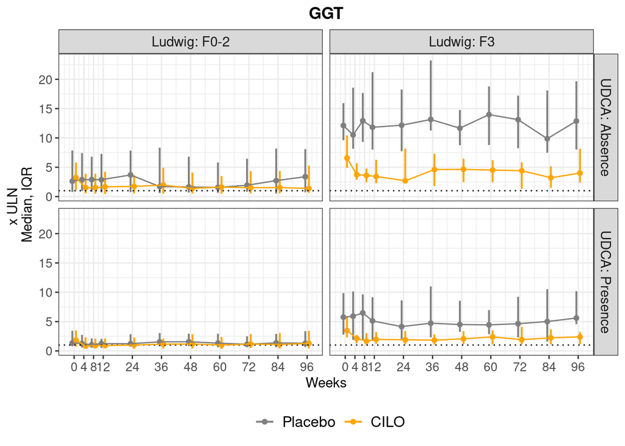

```r
## Summarize by median and IQR
df_chg$PCHG[which(df_chg$AVISIT == 'Baseline')] <- 0

df_summary <- df_chg %>%
  # group_by(PARAMCD, AVISITN, TRT01A) %>%    # if no subgrouping is needed
  group_by(PARAMCD, AVISITN, TRT01A, BLUDWIG_CAT, BUDCA) %>%
  summarise(
    ## Actual values
    # median = median(AVAL, na.rm = TRUE),
    # Q1 = quantile(AVAL, probs = 0.25, na.rm = TRUE),
    # Q3 = quantile(AVAL, probs = 0.75, na.rm = TRUE)

    ## Ratio to ULN
    median = median(R2ANRHI, na.rm = TRUE),
    Q1 = quantile(R2ANRHI, probs = 0.25, na.rm = TRUE),
    Q3 = quantile(R2ANRHI, probs = 0.75, na.rm = TRUE)

    ## %Change from baseline
    # median = median(PCHG, na.rm = TRUE),
    # Q1 = quantile(PCHG, probs = 0.25, na.rm = TRUE),
    # Q3 = quantile(PCHG, probs = 0.75, na.rm = TRUE)

  ) %>%
  drop_na(median) %>%
  rename(Ludwig = BLUDWIG_CAT, UDCA = BUDCA)


biomarker = 'GGT'

ggplot(df_summary[which(df_summary$PARAMCD == biomarker),],
       aes(x = AVISITN, y = median,
           group = TRT01A,
           color = TRT01A)) +
  scale_color_manual(values = c('grey50', 'orange')) +
  geom_point(position = position_dodge(3),
             size = 1.5)+
  geom_errorbar(aes(ymin = Q1, ymax = Q3),
                size = .7,
                width = 0,
                position = position_dodge(3)) +
  geom_hline(yintercept = 1, color = 'black', linetype = 'dotted') +
  geom_line(position = position_dodge(3)) +
  facet_grid(UDCA ~ Ludwig, labeller = label_both)+
  labs(x = 'Weeks',
       y = 'x ULN \nMedian, IQR',
       title = biomarker) +
  theme_bw() +
  scale_x_continuous(breaks=c(0, 4, 8, 12, 24, 36, 48, 60, 72, 84, 96)) +
  theme(legend.position = 'bottom',
        legend.title = element_blank(),
        legend.text = element_text(size = 12),
        strip.text = element_text(size = 11),
        plot.title = element_text(hjust = 0.5, face = 'bold'),
        axis.text = element_text(size = 10),
        axis.title = element_text(size = 11))
```

[^1]: Department of Clinical Bioinformatics & Exploratory Analytics, kaiyi.zhu1@gilead.com